# Getting Started with garchmodels

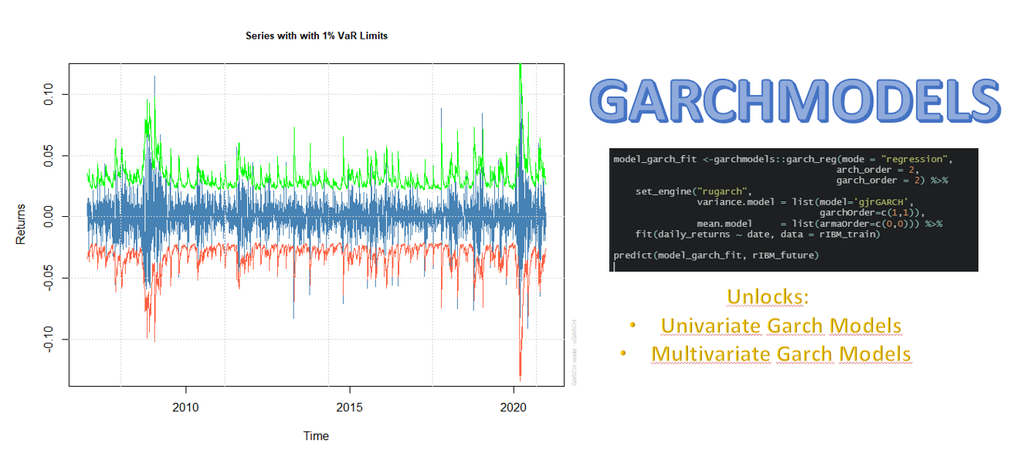

[figure not shown]

This tutorial shows you how you can start using `garchmodels`. The first thing to be clear about is that the package has two main functions:

- **garch_reg**: This function implements the univariate models and currently its only engine is `rugarch`.
- **garch_multivariate_reg**: This function implements the multivariate methods and connects to the rugarch and rmgarch packages. The engines you can currently connect to are the following: `rugarch`, `dcc_rmgarch`, `c_rmgarch` and `gogarch_rmgarch`.

# Univariate Example

First, we load the necessary packages:

```r
library(garchmodels)
library(timetk)
library(tidymodels)
library(tidyverse)
```

```r
rIBM
```

```
#> # A tibble: 3,523 x 2
#>    date       daily_returns
#>    <date>             <dbl>
#>  1 2007-01-03      0.000926
#>  2 2007-01-04      0.0107
#>  3 2007-01-05     -0.00905
#>  4 2007-01-08      0.0152
#>  5 2007-01-09      0.0118
#>  6 2007-01-10     -0.0118
#>  7 2007-01-11     -0.00243
#>  8 2007-01-12      0.00699
#>  9 2007-01-16      0.0149
#> 10 2007-01-17     -0.00793
#> # ... with 3,513 more rows
```

We will extend the dataset to a 3-day horizon forecast and separate the dataset into train and future dataset.

```r
rIBM_extended <- rIBM %>%
    future_frame(.length_out = 3, .bind_data = TRUE)

rIBM_train  <- rIBM_extended %>% drop_na()
rIBM_future <- rIBM_extended %>% filter(is.na(daily_returns))
```

Next, we create the GARCH model for the variance:

```r
model_fit_garch <-garchmodels::garch_reg(mode = "regression",
                                         arch_order = 1,
                                         garch_order = 1,
                                         ma_order = 0,
                                         ar_order = 0) %>%
                  set_engine("rugarch", mean.model = list(include.mean = FALSE)) %>%
                  fit(daily_returns ~ date, data = rIBM_train)
```

We will graphically represent the Series with 1% VaR Limits and the Conditional SD (vs |returns|):

```
#>
#> please wait...calculating quantiles...
```

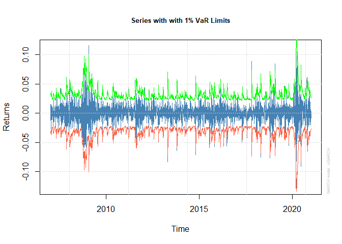

```r
plot(model_fit_garch$fit$models$model_1, which = 2)
```

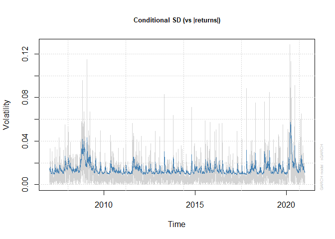

```r
plot(model_fit_garch$fit$models$model_1, which = 3)
```

Let us now predict about the future dataset:

```r
predict(model_fit_garch, rIBM_future)
```

```
#> # A tibble: 2 x 2
#>   .name     .pred
#>   <chr>     <named list>
#> 1 sigmaFor  <dbl[,1] [3 x 1]>
#> 2 seriesFor <dbl[,1] [3 x 1]>
```

We will now create a combined model using a GARCH model for the variance and an ARMA model for the mean:

```r
model_fit_garch <-garchmodels::garch_reg(mode = "regression",
                                         arch_order = 1,
                                         garch_order = 1,
                                         ma_order = 2,
                                         ar_order = 2) %>%
                  set_engine("rugarch") %>%
                  fit(daily_returns ~ date, data = rIBM_train)
```

Let’s again represent the Series with 1% VaR Limits and the Conditional SD (vs |returns|):

```
#>
#> please wait...calculating quantiles...
```

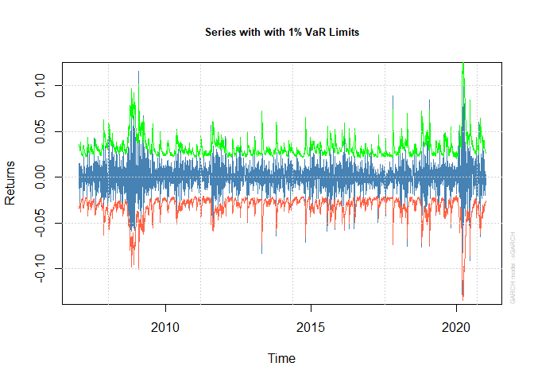

```r
plot(model_fit_garch$fit$models$model_1, which = 2)
```

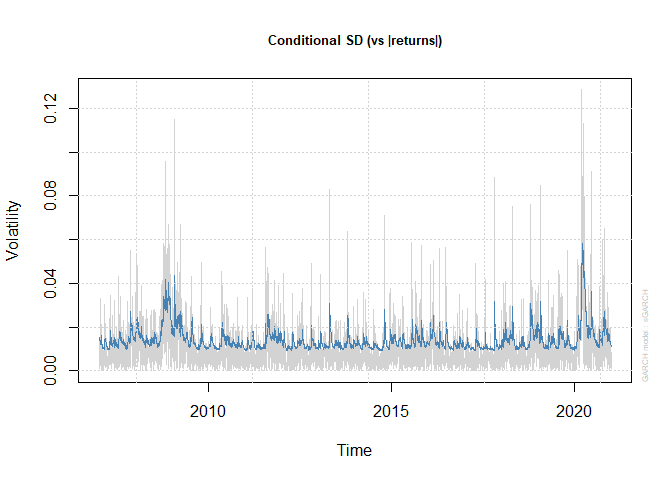

```r
plot(model_fit_garch$fit$models$model_1, which = 3)
```

Let us now predict about the future dataset:

```r
predict(model_fit_garch, rIBM_future)
```

```
#> # A tibble: 2 x 2
#>   .name     .pred
#>   <chr>     <named list>
#> 1 sigmaFor  <dbl[,1] [3 x 1]>
#> 2 seriesFor <dbl[,1] [3 x 1]>
```

# Multivariate Example

```r
rX_longer
```

```
#> # A tibble: 8,550 x 3
#>    id        value date
#>    <chr>     <dbl> <date>
#>  1 rIBM   0.000926 2007-01-03
#>  2 rBP   -0.0192   2007-01-03
#>  3 rGOOG  0.00341  2007-01-03
#>  4 rIBM   0.0107   2007-01-04
#>  5 rBP   -0.0132   2007-01-04
#>  6 rGOOG  0.0335   2007-01-04
#>  7 rIBM  -0.00905  2007-01-05
#>  8 rBP   -0.00215  2007-01-05
#>  9 rGOOG  0.00813  2007-01-05
#> 10 rIBM   0.0152   2007-01-08
#> # ... with 8,540 more rows
```

We will extend the dataset to a 3-day horizon forecast and separate the dataset into train and future dataset.

```r
rX_longer_extended <- rX_longer %>%
    group_by(id) %>%
    future_frame(.length_out = 3, .bind_data = TRUE) %>%
    ungroup()

rX_train  <- rX_longer_extended %>% drop_na()
rX_future <- rX_longer_extended %>% filter(is.na(value))
```

## Rugarch Engine

To create a model with the rugarch engine, the first thing to do is to specify in a list called “specs” through set_engine the specifications of the models. It is also important to note that the formula should always be the return against the date variable followed by the id variable. For more information see ?garch_multivariate_reg.

```r
model_fit <- garch_multivariate_reg(mode = "regression", type = "ugarchspec") %>%
    set_engine("rugarch" , specs = list(spec1 = list(mean.model = list(armaOrder = c(1,0))),
                                        spec2 = list(mean.model = list(armaOrder = c(1,0))),
                                        spec3 = list(mean.model = list(armaOrder = c(1,0)))),
    ) %>%
    fit(value ~ date + id, data = rX_train)
```

We now predict on the future dataset:

```r
predict(model_fit, rX_future)
```

```
#> # A tibble: 18 x 4
#>    .pred_name .pred_value .pred_date$date .pred_.name
#>    <chr>            <dbl> <date>          <chr>
#>  1 rIBM          0.000369 2018-04-28      Series
#>  2 rBP           0.000473 2018-04-28      Series
#>  3 rGOOG         0.000750 2018-04-28      Series
#>  4 rIBM          0.000342 2018-04-29      Series
#>  5 rBP           0.000465 2018-04-29      Series
#>  6 rGOOG         0.000851 2018-04-29      Series
#>  7 rIBM          0.000342 2018-04-30      Series
#>  8 rBP           0.000465 2018-04-30      Series
#>  9 rGOOG         0.000852 2018-04-30      Series
#> 10 rIBM          0.0164   2018-04-28      Sigma
#> 11 rBP           0.0133   2018-04-28      Sigma
#> 12 rGOOG         0.0195   2018-04-28      Sigma
#> 13 rIBM          0.0162   2018-04-29      Sigma
#> 14 rBP           0.0134   2018-04-29      Sigma
#> 15 rGOOG         0.0196   2018-04-29      Sigma
#> 16 rIBM          0.0160   2018-04-30      Sigma
#> 17 rBP           0.0135   2018-04-30      Sigma
#> 18 rGOOG         0.0196   2018-04-30      Sigma
```

## DCC Engine

To create a model with the `dcc_rmgarch` engine, the first thing to do is to specify in a list called **specs** through set_engine the specifications of the models. You can also specify the arguments to be passed to `rmgarch::dccspec()` through the **dcc_specs** list as seen in the following example:

```r
model_fit <- garch_multivariate_reg(type = "ugarchspec") %>%
    set_engine("dcc_rmgarch" , specs = list(spec1 = list(mean.model = list(armaOrder = c(1,0))),
                                            spec2 = list(mean.model = list(armaOrder = c(1,0))),
                                            spec3 = list(mean.model = list(armaOrder = c(1,0)))),
                               dcc_specs = list(dccOrder = c(2,2), distribution = "mvlaplace")) %>%
    fit(value ~ date + id, data = rX_train)
```

Let’s visualize the graphics available through the model:

- Conditional Mean (vs Realized Returns):

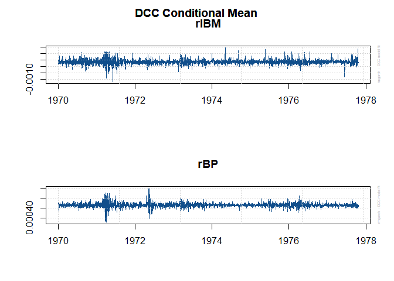

```r
plot(model_fit$fit$models$model_1, which = 1)
```

- Conditional Sigma (vs Realized Absolute Returns)

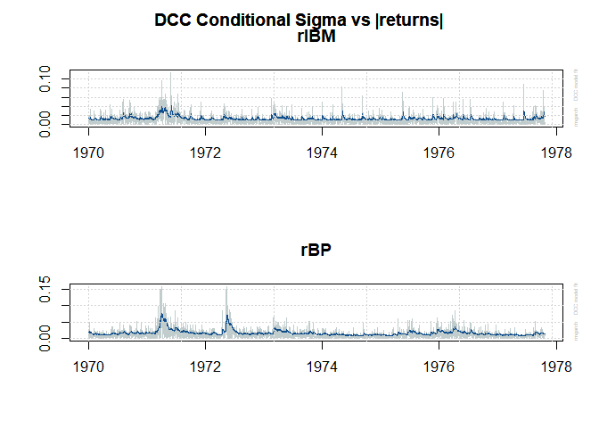

```r
plot(model_fit$fit$models$model_1, which = 2)
```

- Conditional Covariance

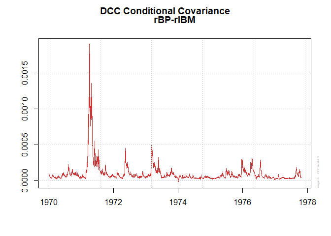

```r
plot(model_fit$fit$models$model_1, which = 3)
```

- Conditional Correlation

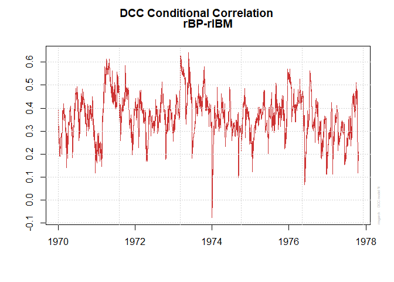

```r
plot(model_fit$fit$models$model_1, which = 4)
```

- EW Portfolio Plot with conditional density VaR limitis

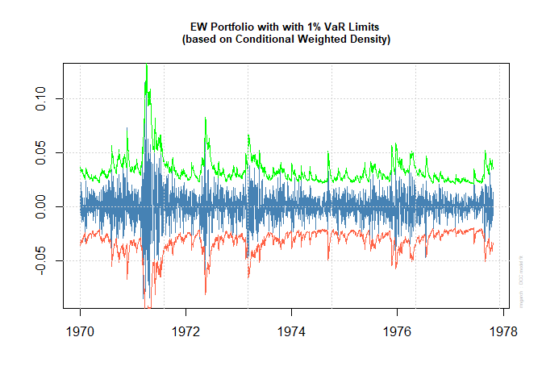

```r
plot(model_fit$fit$models$model_1, which = 5)
```

We now predict on the future dataset:

```r
predictions <- predict(model_fit, rX_future)
```

As you can see, the results are returned in a nested tibble. For example, if you want to get the correlation matrices:

```r
predictions %>% filter(.name == "R") %>% pull(.pred)
```

```
#> $R
#> $R[[1]]
#> , , 1
#>
#>           [,1]      [,2]      [,3]
#> [1,] 1.0000000 0.2245499 0.4009276
#> [2,] 0.2245499 1.0000000 0.3023550
#> [3,] 0.4009276 0.3023550 1.0000000
#>
#> , , 2
#>
#>           [,1]      [,2]      [,3]
#> [1,] 1.0000000 0.2363791 0.3991591
#> [2,] 0.2363791 1.0000000 0.3032042
#> [3,] 0.3991591 0.3032042 1.0000000
#>
#> , , 3
#>
#>           [,1]      [,2]      [,3]
#> [1,] 1.0000000 0.2472140 0.3975391
#> [2,] 0.2472140 1.0000000 0.3039821
#> [3,] 0.3975391 0.3039821 1.0000000
```

## Copula Engine

To create a model with the `c_rmgarch` engine, the first thing to do is to specify in a list called **specs** through set_engine the specifications of the models. You can also specify the arguments to be passed to `rmgarch::cgarchspec()` through the **c_specs** list as seen in the following example:

```r
model_fit <- garch_multivariate_reg(type = "ugarchspec") %>%
    set_engine("c_rmgarch" , specs = list(spec1 = list(mean.model = list(armaOrder = c(1,0))),
                                          spec2 = list(mean.model = list(armaOrder = c(1,0))),
                                          spec3 = list(mean.model = list(armaOrder = c(1,0)))),
                             c_specs = list(dccOrder = c(2,2))) %>%
    fit(value ~ date + id, data = rX_train)

model_fit
```

```
#> parsnip model object
#>
#> Fit time:  2.8s
#> Copula GARCH Multivariate Model
#> $model_1
#>
#> *-------------------------------------------------*
#> *                  Copula GARCH Fit               *
#> *-------------------------------------------------*
#>
#> Distribution     :  mvnorm
#> No. of Parameters    :  15
#> [VAR GARCH CC]       : [0+15+0]
#> No. of Series        :  3
#> No. of Observations  :  2850
#> Log-Likelihood       :  24354.45
#> Av.Log-Likelihood    :  8.545
#>
#> Optimal Parameters
#> ---------------------------------------------------
#>                 Estimate  Std. Error   t value Pr(>|t|)
#> [rIBM].mu       0.000342    0.000243  1.407912 0.159157
#> [rIBM].ar1     -0.013463    0.021468 -0.627106 0.530590
#> [rIBM].omega    0.000015    0.000020  0.768999 0.441894
#> [rIBM].alpha1   0.111158    0.094421  1.177258 0.239093
#> [rIBM].beta1    0.809517    0.129092  6.270842 0.000000
#> [rBP].mu        0.000465    0.000278  1.671176 0.094687
#> [rBP].ar1      -0.000551    0.020888 -0.026386 0.978950
#> [rBP].omega     0.000005    0.000009  0.575227 0.565138
#> [rBP].alpha1    0.080660    0.014273  5.651338 0.000000
#> [rBP].beta1     0.902935    0.026253 34.393855 0.000000
#> [rGOOG].mu      0.000852    0.000307  2.771785 0.005575
#> [rGOOG].ar1     0.009763    0.022858  0.427108 0.669301
#> [rGOOG].omega   0.000010    0.000002  6.681005 0.000000
#> [rGOOG].alpha1  0.087500    0.016032  5.457858 0.000000
#> [rGOOG].beta1   0.887105    0.014877 59.629962 0.000000
#>
#> Information Criteria
#> ---------------------
#>
#> Akaike       -17.080
#> Bayes        -17.049
#> Shibata      -17.080
#> Hannan-Quinn -17.069
#>
#>
#> Elapsed time : 1.267194
```

## Go-Garch Engine

To create a model with the `gogarch_rmgarch` engine, you can specify the arguments to be passed to `rmgarch::gogarchspec()` through the **gogarch_specs** list. You can also specify other arguments that will be passed to `rmgarch::gogarchfit()`:

```r
model_fit <- garch_multivariate_reg(type = "ugarchspec") %>%
         set_engine("gogarch_rmgarch" , gogarch_specs = list(variance.model = list(garchOrder = c(2,2)))) %>%
    fit(value ~ date + id, data = rX_train)
```

We now predict on the future dataset:

```r
predictions <- predict(model_fit, rX_future)
predictions
```

```
#> # A tibble: 11 x 2
#>    .name         .pred
#>    <chr>         <named list>
#>  1 factor.sigmas <dbl[,3,1] [3 x 3 x 1]>
#>  2 mu            <dbl[,3,1] [3 x 3 x 1]>
#>  3 A             <dbl[,3] [3 x 3]>
#>  4 Y             <dbl[,3] [2,850 x 3]>
#>  5 W             <dbl[,3] [3 x 3]>
#>  6 K             <dbl[,3] [3 x 3]>
#>  7 Kinv          <dbl[,3] [3 x 3]>
#>  8 U             <dbl[,3] [3 x 3]>
#>  9 arcoef        <dbl[,3] [2 x 3]>
#> 10 garchcoef     <dbl[,3] [5 x 3]>
#> 11 timer         <drtn [1]>
```

Let’s look at the GARCH model coefficients:

```r
predictions %>% filter(.name == "garchcoef") %>% pull(.pred)
```

```
#> $garchcoef
#>                [,1]         [,2]         [,3]
#> omega  1.194604e-01 2.704742e-02 1.145586e-01
#> alpha1 2.476648e-01 5.574154e-02 1.007045e-01
#> alpha2 5.334348e-10 9.326931e-02 1.112394e-13
#> beta1  2.760104e-01 1.147222e-07 3.368855e-01
#> beta2  4.022703e-01 8.201565e-01 4.506635e-01
```